# Network propagation

2024-12-14

In this tutorial, we demonstrate how to read the SSpMosaic programs generated from multiple samples and calculate program distances using network propagation.

## Loading package

```r
library(SSpMosaic)
library(pheatmap)
```

## Setting the working directory

```r
setwd('./')

current_dir <- getwd()
result_dir <- paste0(current_dir,'/result/')
data_dir <- paste0(current_dir,'/data/')
```

## Loading SSpMosaic programs from multiple samples

The ‘get_all_modules’ function is used to retrieve SSpMosaic programs from multiple samples. The input parameters include the ‘sample_name’ specified in the ‘filter_module’ function and the output directory path. Multiple sample names should be provided as a vector, ensuring that all samples share the same save path.

```r
samples <- c('human_brain1','human_brain2','human_brain3','human_brain4')
moudules <- get_all_modules(sample_names = samples,read_dir = data_dir)
```

## Converting to data frame

Summarize the SSpMosaic programs into a data frame to serve as the input for the `gene_program_network_propagation_dist` function.

```r
max_length <- max(sapply(moudules, length))


df <- do.call(rbind, lapply(moudules, function(x) {

  length(x) <- max_length
  x
}))


df <- as.data.frame(df, stringsAsFactors = FALSE)
```

## Loading ppi matrix

The protein-protein interaction (PPI) matrix is used as a biological background network. Users can choose different biological background networks based on their research needs, such as pathway-based biological networks.

```r
ppi <- readRDS(paste0(data_dir,'human_ppi_matrix.rds'))
```

## Network propagation

Input the biological background network and the summarized program data frame for network propagation to obtain the program distance matrix.

```r
distance_matrix <- gene_program_network_propagation_dist(gene_programs = df,biological_network = ppi)
```

## Hierarchical Clustering

Hierarchical Clustering is used to generate SSpMosaic metaprograms

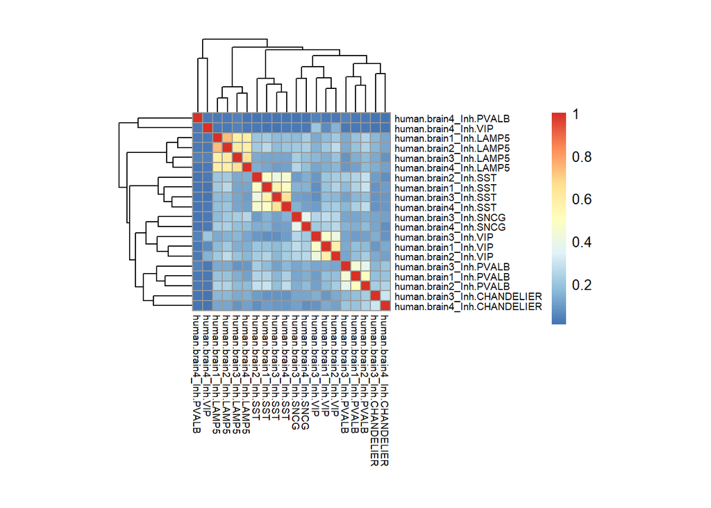

```r
#only keep Inh
distance_matrix <- distance_matrix[grepl('Inh',rownames(distance_matrix)),grepl('Inh',colnames(distance_matrix))]
#drop cell types that only appear in a single sample
distance_matrix <- distance_matrix[!grepl('Inh.PAX6|Inh.ADARB2',rownames(distance_matrix)),!grepl('Inh.PAX6|Inh.ADARB2',colnames(distance_matrix))]
p <- pheatmap::pheatmap(1-distance_matrix,fontsize_row = 7,fontsize_col = 7,cellwidth = 7,cellheight = 7)
```

```r
clusters <- cutree(p$tree_row, k = 8)
```

## Generate SSpMosaic metaprograms

```r
meta_moudule<- list()
unique_clusters <- unique(clusters)
count_string_occurrences <- function(arr, target) {
  count <- sum(grepl(target, arr))
  return(count)
}

for (cluster in unique_clusters) {
  variables <- names(clusters[clusters == cluster])
  extracted_chars <- gsub("^.*_", "", variables)
  u <- unique(extracted_chars)
  meta_name <-  "meta_program"
  for(l in 1:length(u))
  {
    meta_name <- paste(meta_name,u[l],sep = '_')
  }
  if(count_string_occurrences(names(meta_moudule),meta_name) >= 1)
  {

    meta_name <- paste(meta_name,(count_string_occurrences(names(meta_moudule),meta_name)+1),sep = '_')
  }
  meta_moudule[[meta_name]] <- variables
}
```

## Generate the gene sets corresponding to the SSpMosaic metaprograms

```r
meta_moudule_genes <- list()
for(meta in names(meta_moudule))
{
  for(program in meta_moudule[[meta]])
  {
    meta_moudule_genes[[meta]] <- c(meta_moudule_genes[[meta]],moudules[[program]])
  }
}
```